# Projet Visualisation des données - Data Visualization ©

#### Licence Informatique (L3) - 2020-2021

### Groupe "Ville"

Membres du groupe :

- IGUI Said
- MALUEKI NGOMBI Jérémie
- CONDE Moussa
- BERLEMONT Lucas
- DJERROUD Said
- BERKANE Sarah

### Institut Galilée - Université Sorbonne Paris Nord (USPN)

# La pollution aérienne aux abords des écoles et crèches d’Île-de-France

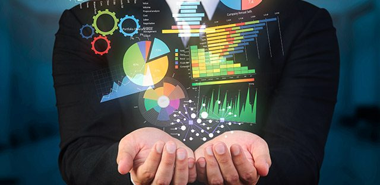

## Présentation de la problématique

### On va essayer de montrer l'évolution de la pollution aérienne sur la période 2012-2017

## Présentation des données

### Description des fichiers :

lien de téléchargement: https://www.data.gouv.fr/fr/datasets/r/e5626b68-4615-41cb-90d0-1f825d520bd9

Ce jeu de données contient des informations sur les principaux polluants notamment les particules en suspension (PM10, PM2,5) et le dioxyde d'azote (NO2) en microgramme par mètre cube (µg/m3) de moyenne journalière annuelle.

PM10 PM2,5: Les particules en suspension (notées « PM » en anglais pour « Particulate matter ») sont d’une manière générale les fines particules solides portées par l’eau ou solides et/ou liquides portées par l’air (Wikipédia). Chaque fichier comporte trois catégories de variables :

les variables descriptives de l'établissement ; les variables rapportant les niveaux d'exposition ; une variable "geometry" correspondant à l'adresse géolocalisée de chaque établissement. Les variables descriptives des établissements sont des chaînes de caractères.

ID : l'identifiant unique de la crèche ou de l'école ; nom : le nom usuel de l'établissement dans les fichiers de référence ; CP : le code postal de l'établissement ; ville : la ville suivant la nomenclature de l'Insee ; type : la catégorie d'établissement (crèche, primaire ou secondaire). Les variables correspondant aux niveaux d'exposition suivent la nomenclature suivante : "polluant_AAAA", AAAA figurant l'année civile sur 4 chiffres. Leurs valeurs numériques sont exprimées en microgrammes par mètre cube en moyenne journalière annuelle.

### Normes de qualité de l’air en France :

#### Objectif de qualité : un niveau de concentration de substances polluantes dans l’atmosphère à atteindre à long terme, sauf lorsque cela n’est pas réalisable par des mesures proportionnées, afin d’assurer une protection efficace de la santé humaine et de l'environnement dans son ensemble

#### Valeur limite : un niveau de concentration de substances polluantes dans l’atmosphère fixé sur la base des connaissances scientifiques à ne pas dépasser dans le but d’éviter, de prévenir ou de réduire les effets nocifs de ces substances sur la santé humaine ou sur l'environnement dans son ensemble

pour le DIOXYDE d’AZOTE (NO2)

- Objectif de qualité : 40 µg/m³ en moyenne annuelle
- Valeurs limites pour la protection de la santé humaine : 40 µg/m³ en moyenne annuelle

pour les PARTICULES PM10

- Objectif de qualité : 30 µg/m³
- Valeurs limites pour la protection de la santé humaine : 40 µg/m³ en moyenne annuelle

pour les PARTICULES PM2,5

- Objectif de qualité : 10 µg/m³ en moyenne annuelle
- Valeurs limites pour la protection de la santé humaine 25 µg/m³ en moyenne annuelle

Source d'information : https://www.airparif.asso.fr/la-reglementation-en-france

## Information sur geopandas

GeoPandas étend les types de données utilisés par pandas pour permettre des opérations spatiales sur des types géométriques. Les opérations géométriques sont effectuées par shapely

Installation de geopandas :

- méthode 1 :
  - documentation geopandas sur le lien https://geopandas.org/getting_started/install.html
  - conda install geopandas
- méthode 2 :
  - télécharger : Fiona, Pyproj, Shapely, GDAL and Geopandas wheels sur le lien : https://www.lfd.uci.edu/~gohlke/pythonlibs/
  - Installer les fichiers.whl manuellement avec pip sur Anaconda Prompt comme suit:
  - pip install *.whl en l'ordre suivant : GDAL, Pyproj, Fiona, Shapely et Geopandas

## Information sur mapclassify

mapclassify implémente une famille de schémas de classification pour les cartes choroplèthes. Il se concentre sur la détermination du nombre de classes et sur l'affectation des observations à ces classes.

Pour installer taper la commande sur anaconda prompt :

- pip install mapclassify

## Information sur les cartes

Ce jeu de données provient d'un service public certifié.

Découpage départemental de la région Île-de-France.

Télécharger et décompressé les fichiers geoflare des départements d'ile-de-France pour pouvoir les utiliser comme une carte de base.

https://www.data.gouv.fr/fr/datasets/r/2dedae24-eb12-4a92-803d-7ceddf08baf8

## Importation des bibliothèques

```python
import pandas as pd
import numpy as np
import matplotlib.pyplot as plt
import geopandas as gpd
import seaborn as sns
import shapely as shp

from geopandas import GeoDataFrame
from shapely.geometry import Point
import shapely.wkt
```

## Lecture des données stockées au format CSV

```python
df = pd.read_csv('ecoles-creches-idf-prepared.csv')
df.head()
```

|  | ID | nom | departement | ville | CP | type | NO2_2012 | NO2_2013 | NO2_2014 | NO2_2015 | ... | PM10_2015 | PM10_2016 | PM10_2017 | PM25_2012 | PM25_2013 | PM25_2014 | PM25_2015 | PM25_2016 | PM25_2017 | geometry |
| --- | --- | --- | --- | --- | --- | --- | --- | --- | --- | --- | --- | --- | --- | --- | --- | --- | --- | --- | --- | --- | --- |
| 0 | 0750026W | L'Enseignement par petits groupes (Ecole secon... | 75 | Paris 15 | 75015 | secondaire | 41.316912 | 42.916257 | 40.610102 | 37.182711 | ... | 23.790138 | 23.077844 | 21.782889 | 17.152857 | 18.637080 | 14.895546 | 15.277787 | 14.806532 | 13.549347 | POINT(2.2908106734441 48.8421565600018) |
| 1 | 0750106H | Ecole technologique privée CCIP Centre des For... | 75 | Paris 20 | 75020 | secondaire | 63.683878 | 60.890328 | 53.322156 | 45.804898 | ... | 26.063983 | 23.803116 | 23.020608 | 22.692531 | 23.629341 | 18.628494 | 16.978740 | 15.434943 | 14.429643 | POINT(2.40580700033425 48.8756657433978) |
| 2 | 0750132L | Ecole primaire privée Notre-Dame-Saint Roch | 75 | Paris 01 | 75001 | primaire | 41.507336 | 41.598420 | 42.855147 | 39.286859 | ... | 22.995246 | 22.400441 | 20.867075 | 16.614189 | 18.142261 | 14.487745 | 14.562495 | 14.134427 | 12.561472 | POINT(2.33270615799049 48.8661396641722) |
| 3 | 0750136R | Ecole primaire privée Saint-Sauveur | 75 | Paris 02 | 75002 | primaire | 45.197342 | 44.280198 | 45.187931 | 40.855468 | ... | 23.650961 | 23.405547 | 22.650735 | 17.713481 | 19.089383 | 15.433904 | 15.067306 | 14.756645 | 15.118740 | POINT(2.34734689771536 48.8668886093452) |
| 4 | 0750138T | Ecole primaire privée Sainte Geneviève du Marais | 75 | Paris 03 | 75003 | primaire | 40.109546 | 39.257252 | 39.688121 | 37.249166 | ... | 22.808231 | 22.049934 | 20.717201 | 16.332941 | 17.645253 | 14.270936 | 14.391215 | 13.911639 | 12.654443 | POINT(2.36480092620121 48.8569700986785) |

5 rows × 25 columns

## la Structure globe de la dataframe

```python
df.shape
```

[output not shown]

```python
df.info()
```

[output not shown]

[output cut: 16 more lines]

## Les types de données

```python
df.dtypes
```

```
ID              object
nom             object
departement      int64
ville           object
CP               int64
type            object
NO2_2012       float64
NO2_2013       float64
NO2_2014       float64
NO2_2015       float64
NO2_2016       float64
NO2_2017       float64
PM10_2012      float64
PM10_2013      float64
PM10_2014      float64
PM10_2015      float64
PM10_2016      float64
PM10_2017      float64
PM25_2012      float64
PM25_2013      float64
PM25_2014      float64
PM25_2015      float64
PM25_2016      float64
PM25_2017      float64
geometry        object
dtype: object
```

```python
# compte le type des valeurs

df.dtypes.value_counts()
```

```
float64    18
object      5
int64       2
dtype: int64
```

## Vérifier les valeurs manquantes et supprimer les lignes nulles ou vides

```python
df.isnull().sum()
```

```
ID               0
nom            180
departement      0
ville            0
CP               0
type            14
NO2_2012         0
NO2_2013         0
NO2_2014         0
NO2_2015         0
NO2_2016         0
NO2_2017         0
PM10_2012        0
PM10_2013        0
PM10_2014        0
PM10_2015        0
PM10_2016        0
PM10_2017        0
PM25_2012        0
PM25_2013        0
PM25_2014        0
PM25_2015        0
PM25_2016        0
PM25_2017        0
geometry         0
dtype: int64
```

```python
df=df.drop(['nom'], axis=1)
df.dropna(subset = ["type"], inplace=True)
df.isnull().sum()
```

```
ID             0
departement    0
ville          0
CP             0
type           0
NO2_2012       0
NO2_2013       0
NO2_2014       0
NO2_2015       0
NO2_2016       0
NO2_2017       0
PM10_2012      0
PM10_2013      0
PM10_2014      0
PM10_2015      0
PM10_2016      0
PM10_2017      0
PM25_2012      0
PM25_2013      0
PM25_2014      0
PM25_2015      0
PM25_2016      0
PM25_2017      0
geometry       0
dtype: int64
```

### S'assurer qu il n y a pas de doublons dans les data set et les supprimer

```python
 df.duplicated().sum()
```

```
10
```

```python
df.drop_duplicates(inplace = True)
df.duplicated().sum()
```

```
0
```

## Premières statistiques

```python
df.describe()
```

|  | departement | CP | NO2_2012 | NO2_2013 | NO2_2014 | NO2_2015 | NO2_2016 | NO2_2017 | PM10_2012 | PM10_2013 | PM10_2014 | PM10_2015 | PM10_2016 | PM10_2017 | PM25_2012 | PM25_2013 | PM25_2014 | PM25_2015 | PM25_2016 | PM25_2017 |
| --- | --- | --- | --- | --- | --- | --- | --- | --- | --- | --- | --- | --- | --- | --- | --- | --- | --- | --- | --- | --- |
| count | 12506.000000 | 12506.000000 | 12506.000000 | 12506.000000 | 12506.000000 | 12506.000000 | 12506.000000 | 12506.000000 | 12506.000000 | 12506.000000 | 12506.000000 | 12506.000000 | 12506.000000 | 12506.000000 | 12506.000000 | 12506.000000 | 12506.000000 | 12506.000000 | 12506.000000 | 12506.000000 |
| mean | 85.791460 | 86077.131777 | 30.187527 | 29.778168 | 28.593044 | 27.042631 | 27.362701 | 26.944864 | 24.567133 | 23.846245 | 20.697122 | 20.442869 | 20.163960 | 19.088258 | 15.127571 | 16.291398 | 13.210519 | 12.954515 | 12.752535 | 11.693634 |
| std | 8.248655 | 8307.975953 | 10.126142 | 10.725121 | 10.955819 | 9.937099 | 9.301334 | 9.493091 | 3.042199 | 2.869623 | 2.533826 | 2.650771 | 2.464275 | 2.378765 | 2.162017 | 2.106454 | 1.937048 | 1.820191 | 1.618873 | 1.530097 |
| min | 75.000000 | 75001.000000 | 6.028835 | 8.146600 | 4.234614 | 2.114619 | 6.458028 | 6.614352 | 18.910143 | 18.129007 | 16.483458 | 15.301406 | 14.116367 | 13.405192 | 11.535187 | 12.327724 | 9.140570 | 9.639885 | 8.893311 | 8.177167 |
| 25% | 77.000000 | 77400.000000 | 23.382761 | 22.126075 | 21.618274 | 21.031343 | 21.291666 | 20.320945 | 22.374104 | 22.121004 | 19.003973 | 18.667334 | 18.699708 | 17.577965 | 13.667050 | 15.050677 | 12.180268 | 11.770182 | 11.798442 | 10.726504 |
| 50% | 91.000000 | 91370.000000 | 28.932307 | 29.161972 | 28.001950 | 26.747057 | 27.621532 | 27.521562 | 24.432876 | 23.765534 | 20.284902 | 20.110855 | 20.265133 | 19.497410 | 14.943914 | 16.182190 | 13.012107 | 12.702582 | 12.780819 | 11.907139 |
| 75% | 93.000000 | 93350.000000 | 36.175628 | 36.854918 | 35.907879 | 33.470558 | 33.270432 | 33.609808 | 26.229764 | 25.262879 | 22.087487 | 21.897649 | 21.469892 | 20.357598 | 16.032858 | 17.208728 | 14.141435 | 13.826947 | 13.557049 | 12.436002 |
| max | 95.000000 | 95880.000000 | 110.617037 | 106.035061 | 100.038686 | 93.268892 | 88.598092 | 89.975508 | 50.651498 | 49.461991 | 44.225924 | 42.598372 | 43.149841 | 42.693255 | 32.135413 | 31.689544 | 26.352102 | 26.414602 | 21.143228 | 19.561912 |

On repère déja que les maximum de la concentration des polluants sont très elevé et bien au dessus des normes. On constate également une baisse de la concentration entre 2012 et 2017 pour tout les polluants.

## Découpage des données

On sépare les données selon l'année de 2012 à 2017 et on y a ajouté une nouvelle colonne "année" pour faciliter la manipulation.

```python
df2012 = pd.DataFrame({
    "ID" : df["ID"],
    'departement': df['departement'],
    "type": df["type"],
    "ville": df["ville"],
    "NO2" : df["NO2_2012"],
    "PM10" : df["PM10_2012"],
    "PM25" : df["PM25_2012"],
    "geometry": df["geometry"]
})
df2013 = pd.DataFrame({
    "ID" : df["ID"],
    'departement': df['departement'],
    "type": df["type"],
    "ville": df["ville"],
    "NO2" : df["NO2_2013"],
    "PM10" : df["PM10_2013"],
    "PM25" : df["PM25_2013"],
    "geometry": df["geometry"]
})
df2014 = pd.DataFrame({
     "ID" : df["ID"],
    "departement": df["departement"],
    "type": df["type"],
     "ville": df["ville"],
    "NO2" : df["NO2_2014"],
    "PM10" : df["PM10_2014"],
    "PM25" : df["PM25_2014"],
    "geometry": df["geometry"]
})

df2015 = pd.DataFrame({
     "ID" : df["ID"],
    "departement": df["departement"],
    "type": df["type"],
     "ville": df["ville"],
    "NO2" : df["NO2_2015"],
    "PM10" : df["PM10_2015"],
    "PM25" : df["PM25_2015"],
    "geometry": df["geometry"]
})

df2016 = pd.DataFrame({
     "ID" : df["ID"],
     "departement": df["departement"],
    "type": df["type"],
     "ville": df["ville"],
    "NO2" : df["NO2_2016"],
    "PM10" : df["PM10_2016"],
    "PM25" : df["PM25_2016"],
    "geometry": df["geometry"]
})

df2017 = pd.DataFrame({
     "ID" : df["ID"],
    "departement": df["departement"],
    "type": df["type"],
     "ville": df["ville"],
    "NO2" : df["NO2_2017"],
    "PM10" : df["PM10_2017"],
    "PM25" : df["PM25_2017"],
    "geometry": df["geometry"]
})
df2012["annee"]='01-01-2012'
df2013["annee"]='01-01-2013'
df2014["annee"]='01-01-2014'
df2015["annee"]='01-01-2015'
df2016["annee"]='01-01-2016'
df2017["annee"]='01-01-2017'
df_annee=pd.concat([df2012,df2013,df2014,df2015,df2016,df2017])
df_annee['annee']  = pd.to_datetime(df_annee['annee'])
```

```python
df2012.head()
```

|  | ID | departement | type | ville | NO2 | PM10 | PM25 | geometry | annee |
| --- | --- | --- | --- | --- | --- | --- | --- | --- | --- |
| 0 | 0750026W | 75 | secondaire | Paris 15 | 41.316912 | 27.311257 | 17.152857 | POINT(2.2908106734441 48.8421565600018) | 01-01-2012 |
| 1 | 0750106H | 75 | secondaire | Paris 20 | 63.683878 | 34.043706 | 22.692531 | POINT(2.40580700033425 48.8756657433978) | 01-01-2012 |
| 2 | 0750132L | 75 | primaire | Paris 01 | 41.507336 | 27.037523 | 16.614189 | POINT(2.33270615799049 48.8661396641722) | 01-01-2012 |
| 3 | 0750136R | 75 | primaire | Paris 02 | 45.197342 | 28.331593 | 17.713481 | POINT(2.34734689771536 48.8668886093452) | 01-01-2012 |
| 4 | 0750138T | 75 | primaire | Paris 03 | 40.109546 | 26.688789 | 16.332941 | POINT(2.36480092620121 48.8569700986785) | 01-01-2012 |

```python
df_annee.tail()
```

|  | ID | departement | type | ville | NO2 | PM10 | PM25 | geometry | annee |
| --- | --- | --- | --- | --- | --- | --- | --- | --- | --- |
| 12525 | 12192 | 92 | crèche | Vaucresson | 22.381235 | 18.105259 | 11.044208 | POINT(2.16919587783002 48.8431345916851) | 2017-01-01 |
| 12526 | 12193 | 92 | crèche | Rueil-Malmaison | 23.277292 | 18.478601 | 11.271947 | POINT(2.16847695611124 48.8776984436972) | 2017-01-01 |
| 12527 | 12194 | 92 | crèche | Clamart | 27.989549 | 19.531801 | 11.889488 | POINT(2.26667090146341 48.8064248969638) | 2017-01-01 |
| 12528 | 12195 | 92 | crèche | Neuilly-sur-Seine | 33.622643 | 20.285548 | 12.218995 | POINT(2.26211365820375 48.8873574601706) | 2017-01-01 |
| 12529 | 12196 | 92 | crèche | Neuilly-sur-Seine | 33.389996 | 20.019353 | 12.212256 | POINT(2.26977404178629 48.8854199935976) | 2017-01-01 |

```python
# compte le type des valeurs

df_annee.dtypes.value_counts()
```

```
object            4
float64           3
int64             1
datetime64[ns]    1
dtype: int64
```

## Le nombres d'écoles par types en Ile-de-France

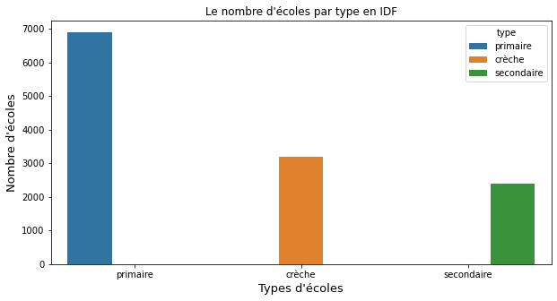

```python
test = df['type'].value_counts().rename_axis('type').reset_index(name='counts')
plt.subplots(figsize=(10, 5))
plt.title("Le nombre d'écoles par type en IDF")
sns.barplot(x="type", y="counts", data=test,hue='type')
plt.ylabel("Nombre d'écoles", fontsize = 13)
plt.xlabel("Types d'écoles", fontsize = 13)
```

```python
df['type'].value_counts()
```

```
primaire      6899
crèche        3203
secondaire    2404
Name: type, dtype: int64
```

### On peut voir qu'il y a bien plus d'école primaires que les autres types en île-de-France

Il y a presque 3200 crèches, 7000 écoles primaires et 2400 écoles secondaire. Tous les enfants en bas âge de ces établissements sont donc exposé au gaz et particules polluantes il y a donc un risque de danger.

## Moyenne par département pour les polluants

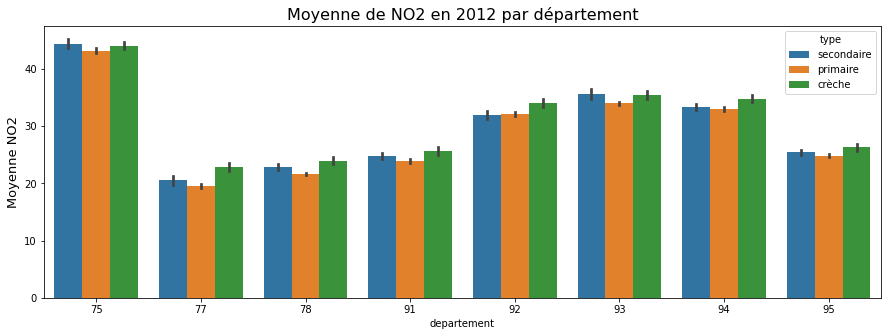

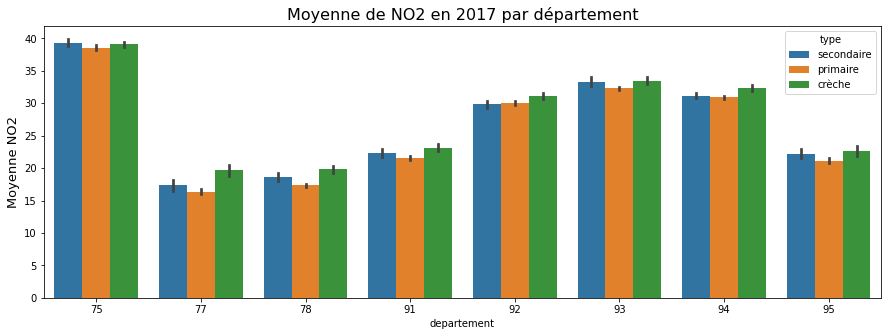

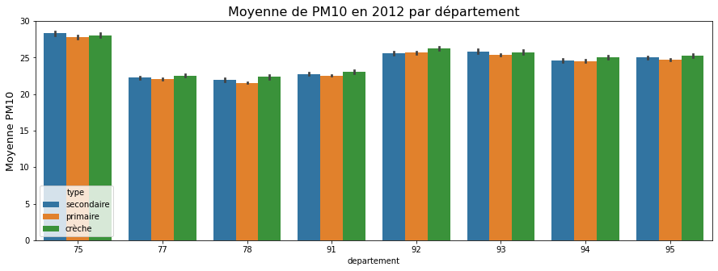

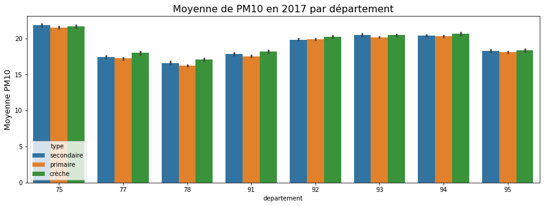

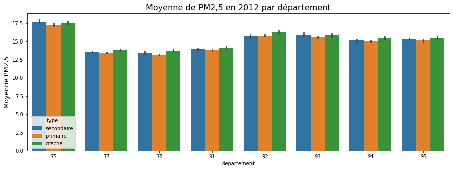

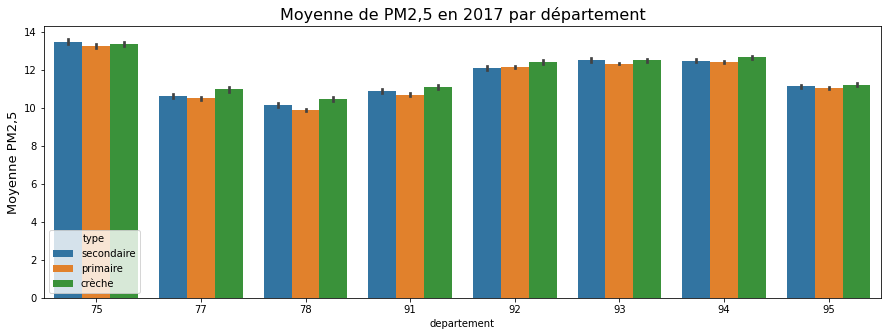

```python
f, ax = plt.subplots(figsize=(15, 5))
plt.title('Moyenne de NO2 en 2012 par département',fontsize = 16)
sns.barplot(data=df2012, x=df2012.departement, y=df2012.NO2, hue = 'type')
plt.ylabel("Moyenne NO2", fontsize = 13)


f, ax = plt.subplots(figsize=(15, 5))
plt.title('Moyenne de NO2 en 2017 par département',fontsize = 16)
sns.barplot(data=df2017, x=df2017.departement, y=df2017.NO2, hue = 'type')
plt.ylabel("Moyenne NO2", fontsize = 13)

f, ax = plt.subplots(figsize=(15, 5))
plt.title('Moyenne de PM10 en 2012 par département',fontsize = 16)
sns.barplot(data=df2012, x=df2012.departement, y=df2012.PM10, hue = 'type')
plt.ylabel("Moyenne PM10", fontsize = 13)

f, ax = plt.subplots(figsize=(15, 5))
plt.title('Moyenne de PM10 en 2017 par département',fontsize = 16)
sns.barplot(data=df2017, x=df2017.departement, y=df2017.PM10, hue = 'type')
plt.ylabel("Moyenne PM10", fontsize = 13)

f, ax = plt.subplots(figsize=(15, 5))
plt.title('Moyenne de PM2,5 en 2012 par département',fontsize = 16)
sns.barplot(data=df2012, x=df2012.departement, y=df2012.PM25, hue = 'type')
plt.ylabel("Moyenne PM2,5", fontsize = 13)

f, ax = plt.subplots(figsize=(15, 5))
plt.title('Moyenne de PM2,5 en 2017 par département',fontsize = 16)
sns.barplot(data=df2017, x=df2017.departement, y=df2017.PM25, hue = 'type')
plt.ylabel("Moyenne PM2,5", fontsize = 13)
```

## Valeur moyenne des polluants en ile-de-france entre 2012-2017

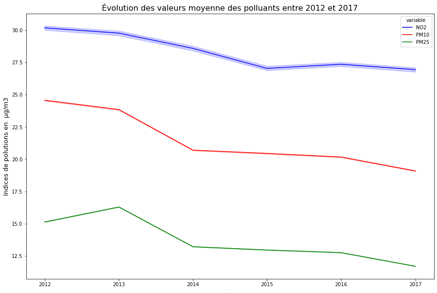

```python
plt.subplots(figsize=(15, 10))
# Thème

dfGLE= df_annee[['NO2','PM10','PM25','annee']]

# Lineplot
sns.lineplot(data=pd.melt(dfGLE, ['annee']), x="annee", y="value", hue='variable',palette=['blue','red','green'])

plt.title('Évolution des valeurs moyenne des polluants entre 2012 et 2017', fontsize = 16)
plt.xlabel("Annee", fontsize = 1)
plt.ylabel("Indices de polutions en  µg/m3",fontsize = 13)
```

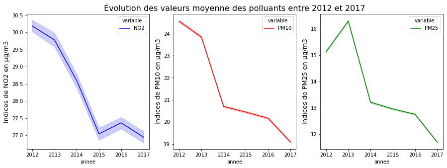

```python
plt.subplots(figsize=(15, 5))
# Thème


dfNO2= df_annee[['NO2','annee']]
dfPM10=df_annee[['PM10','annee']]
dfPM25=df_annee[['PM25','annee']]
plt.subplot(1,3, 1)
# Lineplot
plt.ylabel("Indices de NO2 en µg/m3",fontsize = 13)
sns.lineplot(data=pd.melt(dfNO2, ['annee']), x="annee", y="value", hue='variable', palette=['blue'])
plt.subplot(1, 3, 2)
plt.ylabel("Indices de PM10 en µg/m3",fontsize = 13)
plt.title('Évolution des valeurs moyenne des polluants entre 2012 et 2017', fontsize = 16)
sns.lineplot(data=pd.melt(dfPM10, ['annee']), x="annee", y="value", hue='variable', palette=['red'])
plt.subplot(1, 3, 3)
sns.lineplot(data=pd.melt(dfPM25, ['annee']), x="annee", y="value", hue='variable', palette=['green'])

plt.ylabel("Indices de PM25 en µg/m3",fontsize = 13)
```

### On observe que la valeur moyenne des polluants a globalement diminué au fil des années.

# Visualisation cartographique

### On initialise la carte d'Île-de-France avec Geopandas

on charge la carte d'île-de-france de format .shp (shapely) et on y applique la fonction shapely.wkt.loads pour mettre la colonne geometry en format geopandas dataframe avec un système de référence de coordonnées crs="EPSG:3857" .

```python
carte_IDF=gpd.read_file(r'geoflar-departements.shp')
geometry1 = df2012['geometry'].map(shapely.wkt.loads)
geometry2 = df2017['geometry'].map(shapely.wkt.loads)
geo2012 = gpd.GeoDataFrame(df2012, crs="EPSG:3857", geometry=geometry1)
geo2017 = gpd.GeoDataFrame(df2017, crs="EPSG:3857", geometry=geometry2)
```

### Les couleurs du bleu au rouge représentent le niveau des Polluants dans chaque établissement scolaire représenté par des points.

## Carte NO2 2012

Valeur limite : 40 µg/m³ et objectif de qualité : 40 µg/m³

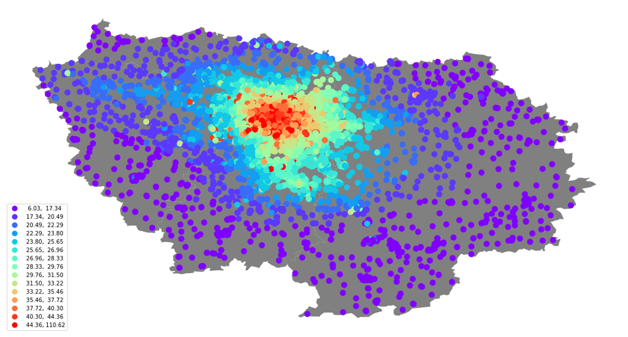

```python
carte_base = carte_IDF.plot( color = 'grey',figsize=(20,20))
geo2012.plot(ax=carte_base, column='NO2', legend=True,cmap= 'rainbow', scheme='quantiles',k=15,markersize=100).set_axis_off()
```

### Contrairement à la visualisation graphique on constate sur la carte que en 2012 la concentration de NO2 était très elevé notamment dans la petite couronne et à Paris. Avec des valeurs qui dépassent 40 µg/m³ avec un maximum à 110 µg/m³ à Paris

## Carte NO2 2017

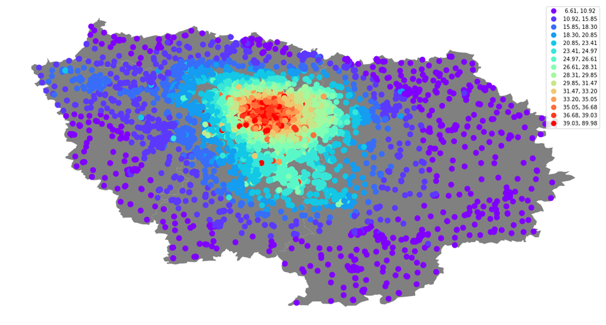

```python
carte_base = carte_IDF.plot( color = 'grey',figsize=(20,20))
geo2017.plot(ax=carte_base, column='NO2', legend=True,cmap= 'rainbow', scheme='quantiles',k=15, markersize=100).set_axis_off()
```

### On constate sur la carte qu'en 2017 la concentration de NO2 était a baissé dans toute la région. Mais il y a toujours des valeurs qui dépassent 40 µg/m³ avec un maximum à 89,9 µg/m³ à Paris. Ce qui montre une amélioration de la qualité de l'air